# NYPD Shooting Incident Data Analysis

## Introduction

This data report aims to find out the trend and relationship of the number of victims and number of criminals for the past 21 years using the data set of NYPD Shooting Incident Data. The hypothesis is that the number of victims of the shooting incident in New York gradually decreased for the past 21 years, and the number of arrested criminals increased for the past 21 years.

## Import Data

First Step: importing NYPD Shooting Incident Data from an online resource, “https://data.cityofnewyork.us/api/views/833y-fsy8/rows.csv?accessType=DOWNLOAD”.

```r
raw_data <-"https://data.cityofnewyork.us/api/views/833y-fsy8/rows.csv?accessType=DOWNLOAD"
```

```r
shooting_data <-readr:::read_csv(raw_data)
```

## Clearing Data

Second step: I cleared data for analyzing data of shooting incidents in New York in the past 21 years. The data columns I need for this analysis are “OCCUR_DATE”,“OCCUR_TIME”,“BORO”,“PERP_AGE_GROUP”,“PERP_SEX”, “PERP_RACE”, “VIC_AGE_GROUP”, “VIC_SEX”, “VIC_RACE”.

- The data type of “OCCUR_DATE” is “character.” To better sort this data set, I changed its data type to “DATE.”
- I only want to study the shooting incident for the past 21 years, so I filtered data, which its “OCCUR_DATE” is between “2000-01-01” and “2020-12-30”.
- Also, to clear out the invalid data, I filtered the rows that contain the NULL VIC_AGE_GROUP, VIC_SEX, and VIC_RACE.

```r
shooting_data<-shooting_data %>%
  select("OCCUR_DATE","OCCUR_TIME","BORO","PERP_AGE_GROUP","PERP_SEX", "PERP_RACE", "VIC_AGE_GROUP", "VIC_SEX", "VIC_RACE")
```

```r
shooting<-shooting_data %>%
  mutate(OCCUR_DATE=mdy(OCCUR_DATE))%>%
  filter(OCCUR_DATE >= ymd("2000-01-01")&OCCUR_DATE <= ymd("2020-12-30"))%>%
  filter(VIC_AGE_GROUP!="NA"& VIC_SEX!="NA"& VIC_RACE!="NA" )
```

## Transforming Data

Third step: I transformed data in order to better study the shooting data. * To better count the number of victim, I first added the number of victim (1) as “countVit” for each record.

- To have a general view of shooting data, I created “shooting_per_month”, which summarizes the total shooting incident of each month for the past 21 years.
- To compare shooting data among different years, I created “shooting_per_year”, which summarizes the total shooting incident, total escaped criminal, and total criminal caught.
- “shooting_per_Year_per_AgeGroup” is created by grouping the month, year, and age group of victim.
- “shooting_compare” is created by combining the “shooting_NA_prep” table, which summarizes the total escaped criminal, and the “shooting_per_year”, which summarizes total criminal caught.

```r
shooting_modify<-shooting%>%
  mutate(countVit=1)

shooting_per_month<-shooting_modify%>%
  mutate( year = format(OCCUR_DATE, "%Y"), month = format(OCCUR_DATE, "%m")) %>%
  group_by(year, month) %>%
  summarise(total_shooting=sum(countVit))
shooting_per_month<-shooting_per_month%>%
  unite("month_year", c(year,month), sep=",", na.rm=TRUE, remove=FALSE)

shooting_per_year<-shooting_modify%>%
  mutate( year = format(OCCUR_DATE, "%Y")) %>%
  group_by(year) %>%
  summarise(total_shooting=sum(countVit))

shooting_NA_prep<-shooting_modify%>%
  filter(PERP_AGE_GROUP!="NA")%>%
  mutate(year = format(OCCUR_DATE, "%Y")) %>%
  group_by(year) %>%
  summarise(total_escaped_criminal=sum(countVit))

shooting_per_Year_per_AgeGroup<-shooting_modify%>%
  mutate( year = format(OCCUR_DATE, "%Y"), month = format(OCCUR_DATE, "%m")) %>%
  group_by(year, month, VIC_AGE_GROUP) %>%
  summarise(total_shooting=sum(countVit))
shooting_compare<-shooting_NA_prep%>%
  left_join(shooting_per_year, by=c("year"))%>%
  mutate(shooting_criminal_caught=total_shooting-total_escaped_criminal)
```

## Plots

```
## geom_path: Each group consists of only one observation. Do you need to adjust
## the group aesthetic?
```

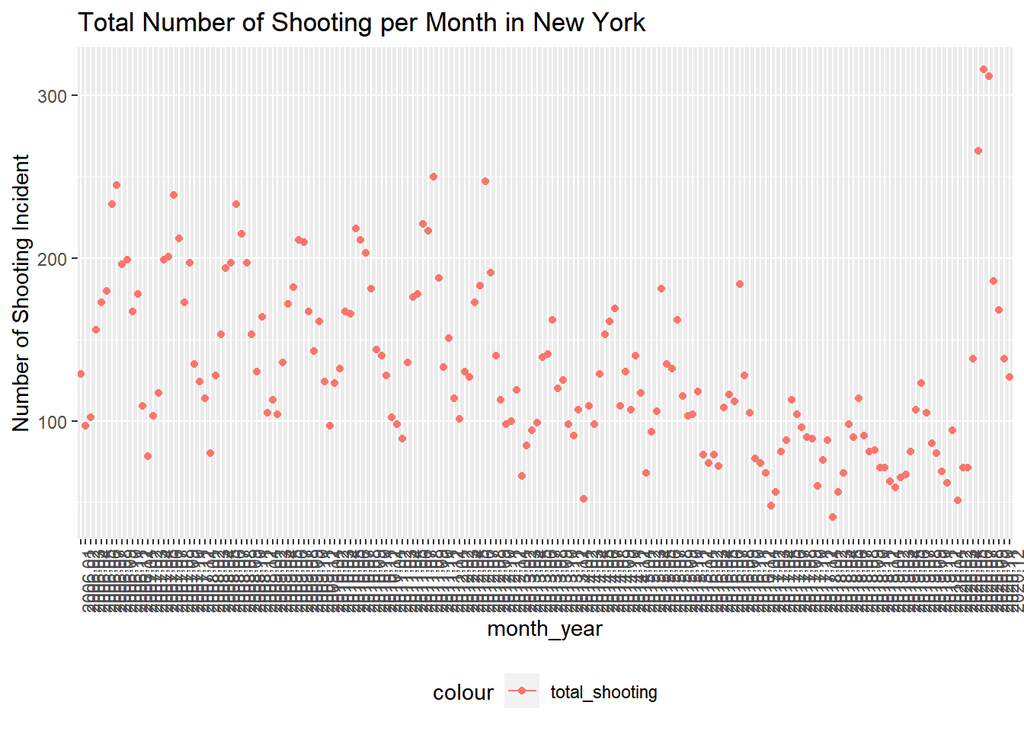

```r
shooting_per_month%>%
  filter(total_shooting>0) %>%
  ggplot(aes(x=month_year, y=total_shooting)) +
  geom_line(aes(color="total_shooting"))+
  geom_point(aes(color="total_shooting"))+
  theme(legend.position = "bottom",
        axis.text.x = element_text(angle = 90))+
  labs(title = "Total Number of Shooting per Month in New York", y="Number of Shooting Incident")
```

[output not shown]

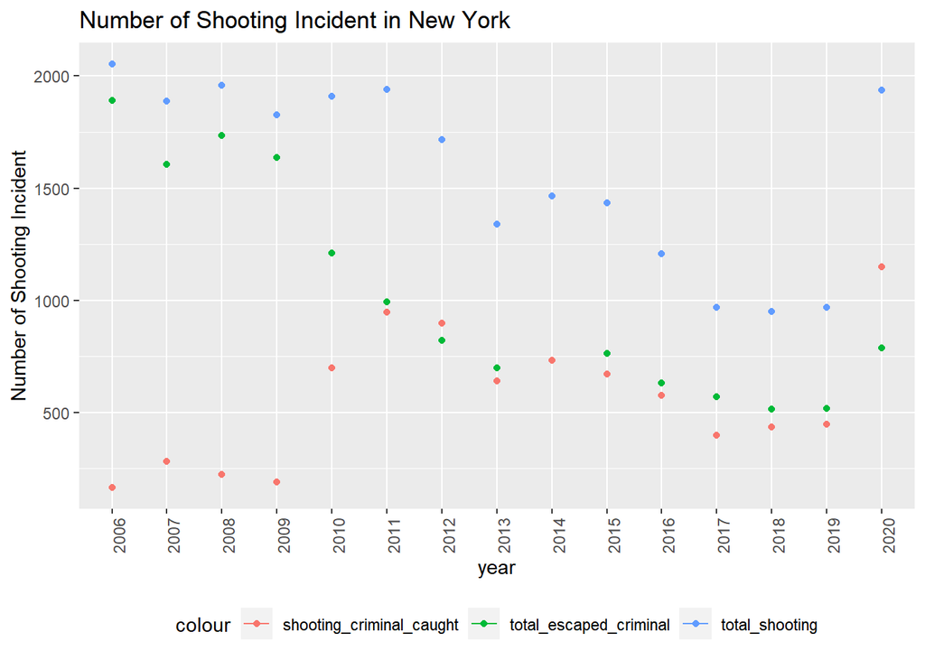

```r
shooting_compare%>%
  filter(total_shooting>0) %>%
  ggplot(aes(x=year, y=total_shooting)) +
  geom_line(aes(color="total_shooting"))+
  geom_point(aes(color="total_shooting"))+
  geom_line(aes(y=total_escaped_criminal,color="total_escaped_criminal"))+
  geom_point(aes(y=total_escaped_criminal,color="total_escaped_criminal"))+
  geom_line(aes(y=shooting_criminal_caught,color="shooting_criminal_caught"))+
  geom_point(aes(y=shooting_criminal_caught,color="shooting_criminal_caught"))+
  theme(legend.position = "bottom",
        axis.text.x = element_text(angle = 90))+
  labs(title = "Number of Shooting Incident in New York", y="Number of Shooting Incident")
```

## Analyzing Data

The groups of people who are most often being shot are male African Americans, age 18-44.

```r
number_vic<-shooting%>%
  count(VIC_AGE_GROUP,VIC_SEX, VIC_RACE, sort = TRUE)
number_vic
```

```
## # A tibble: 78 x 4
##    VIC_AGE_GROUP VIC_SEX VIC_RACE           n
##    <chr>         <chr>   <chr>          <int>
##  1 25-44         M       BLACK           6813
##  2 18-24         M       BLACK           6075
##  3 <18           M       BLACK           1586
##  4 25-44         M       WHITE HISPANIC  1348
##  5 18-24         M       WHITE HISPANIC  1221
##  6 25-44         M       BLACK HISPANIC   876
##  7 18-24         M       BLACK HISPANIC   800
##  8 45-64         M       BLACK            783
##  9 25-44         F       BLACK            547
## 10 18-24         F       BLACK            485
## # ... with 68 more rows
```

```r
number_pert<-shooting%>%
  count(PERP_AGE_GROUP,PERP_SEX,PERP_RACE, sort = TRUE)

number_pert
```

```
## # A tibble: 74 x 4
##    PERP_AGE_GROUP PERP_SEX PERP_RACE          n
##    <chr>          <chr>    <chr>          <int>
##  1 <NA>           <NA>     <NA>            8421
##  2 18-24          M        BLACK           3844
##  3 25-44          M        BLACK           3249
##  4 UNKNOWN        U        UNKNOWN         1436
##  5 UNKNOWN        M        BLACK           1233
##  6 <18            M        BLACK            975
##  7 18-24          M        WHITE HISPANIC   831
##  8 25-44          M        WHITE HISPANIC   654
##  9 18-24          M        BLACK HISPANIC   490
## 10 25-44          M        BLACK HISPANIC   323
## # ... with 64 more rows
```

```r
number_shooting_per_area<-shooting%>%
  count(BORO, sort = TRUE)
number_shooting_per_area
```

```
## # A tibble: 5 x 2
##   BORO              n
##   <chr>         <int>
## 1 BROOKLYN       9722
## 2 BRONX          6699
## 3 QUEENS         3525
## 4 MANHATTAN      2920
## 5 STATEN ISLAND   698
```

```r
number_shooting_in_brooklyn<-shooting%>%
  filter(BORO=="BROOKLYN")%>%
  count(BORO,PERP_AGE_GROUP,PERP_SEX,PERP_RACE, sort = TRUE)
number_shooting_in_brooklyn
```

```
## # A tibble: 58 x 5
##    BORO     PERP_AGE_GROUP PERP_SEX PERP_RACE          n
##    <chr>    <chr>          <chr>    <chr>          <int>
##  1 BROOKLYN <NA>           <NA>     <NA>            3968
##  2 BROOKLYN 18-24          M        BLACK           1668
##  3 BROOKLYN 25-44          M        BLACK           1359
##  4 BROOKLYN UNKNOWN        U        UNKNOWN          628
##  5 BROOKLYN UNKNOWN        M        BLACK            599
##  6 BROOKLYN <18            M        BLACK            437
##  7 BROOKLYN 18-24          M        WHITE HISPANIC   135
##  8 BROOKLYN 25-44          M        WHITE HISPANIC   124
##  9 BROOKLYN 45-64          M        BLACK            108
## 10 BROOKLYN 18-24          M        BLACK HISPANIC   100
## # ... with 48 more rows
```